## Gráficos

- Os gráficos são apresentados em janelas gráficas.
- Normalmente há uma única janela gráfica e esta sempre apresentará o último gráfico solicitado.
- É possível abrir varias janelas gráficas. Comando: X11()

## A função plot()

- Função gráfica genérica do R.

*plot(x, y, type=“p”, …)*

## Multiplos gráficos na Janela ativa

par(mfrow=c(l ,c ))

## Criando dados simulados

```r
 set.seed(333)
 x = runif(100)
 y = 4*x+rnorm(100)
 grp = factor(rep(1:5,20))
 grpl = factor(rep(LETTERS[1:5],c(15,35,22,40,8)))
 gg=factor(rep(c("G_A","G_B","G_C"),c(40,45,35)))
gg=sample(gg)
```

## plot - Argumentos (principais)

Os principais argumentos da função *plot()*

- *type*: tipo de gráfico (linhas, pontos, …)
- *main*: título
- *xlab* e *ylab*: título dos eixos
- *col*: cor (veja *colors()*)

## Gráfico de pontos

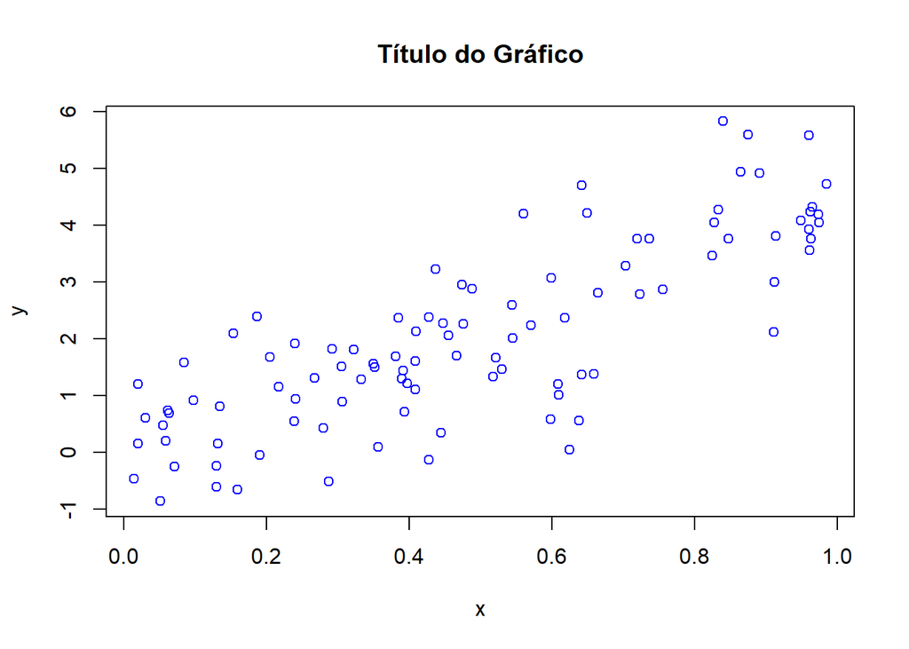

```r
plot(x,y,type="p",main="Título do Gráfico",
xlab="x",ylab="y",col="blue")
```

## Gráfico de pontos

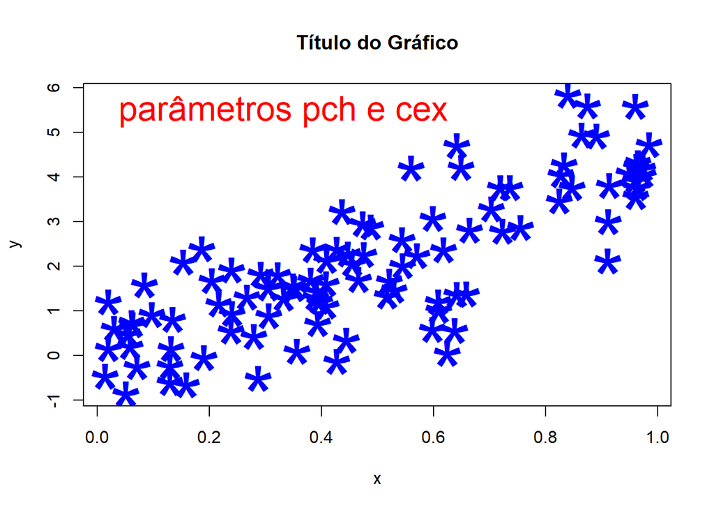

```r
plot(x,y,type="p",main="Título do Gráfico",
xlab="x",ylab="y",col="blue", pch="*",cex=3)
```

## Gráfico de linhas

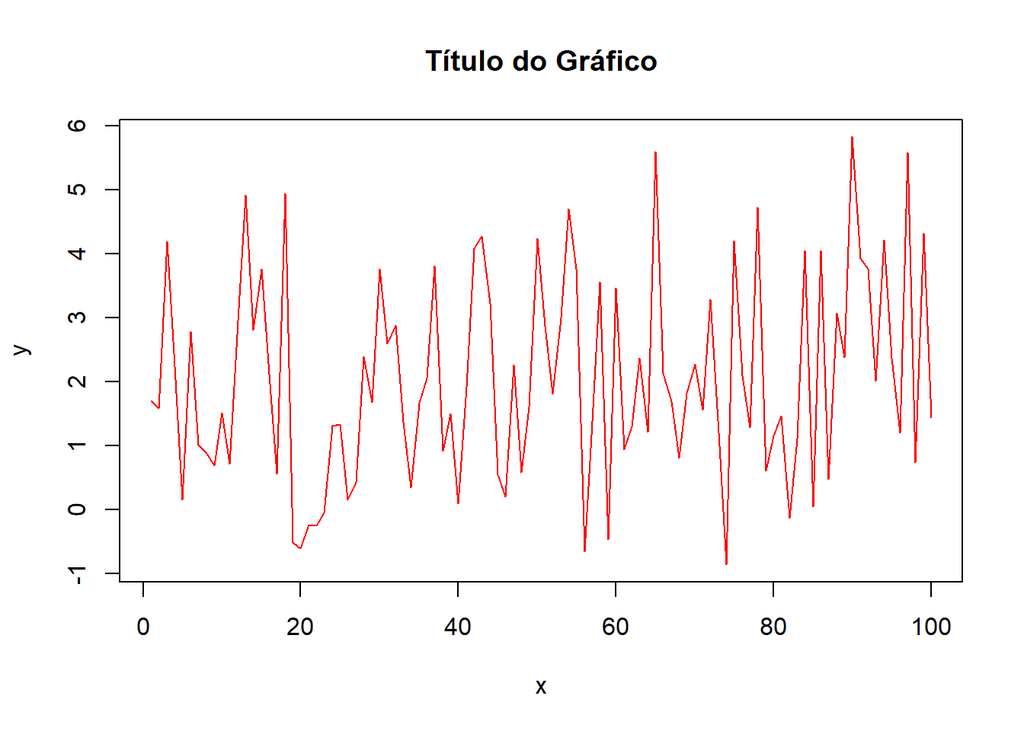

```r
plot(y,type="l",main="Título do Gráfico",
xlab="x",ylab="y",col="red")
```

## Gráfico de linhas- opções

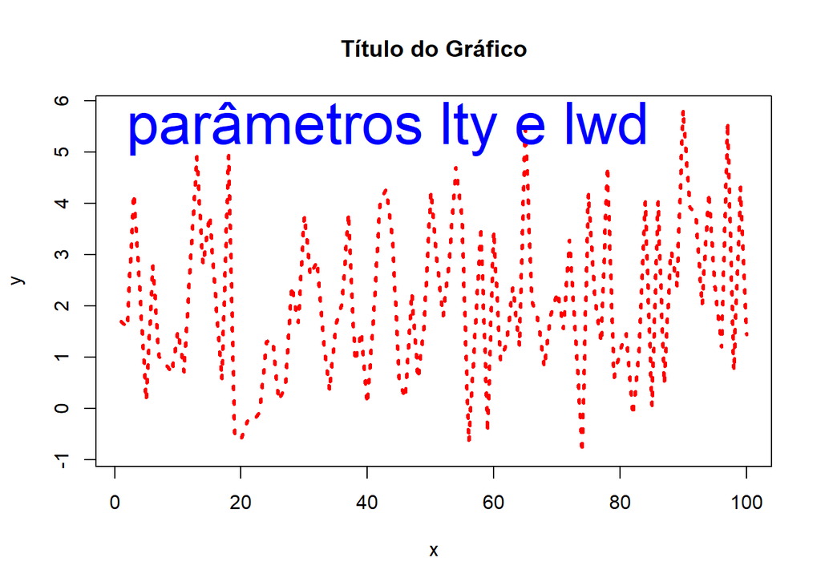

```r
plot(y,type="l",main="Título do Gráfico",
xlab="x",ylab="y",col="red",lty=3, lwd=3)
```

## barplot

[figure not shown]

```r
 barplot(table(grpl),angle = 15+10*1:5, density = 20,
         main="barplot",col="red")
```

## barplot -vertical

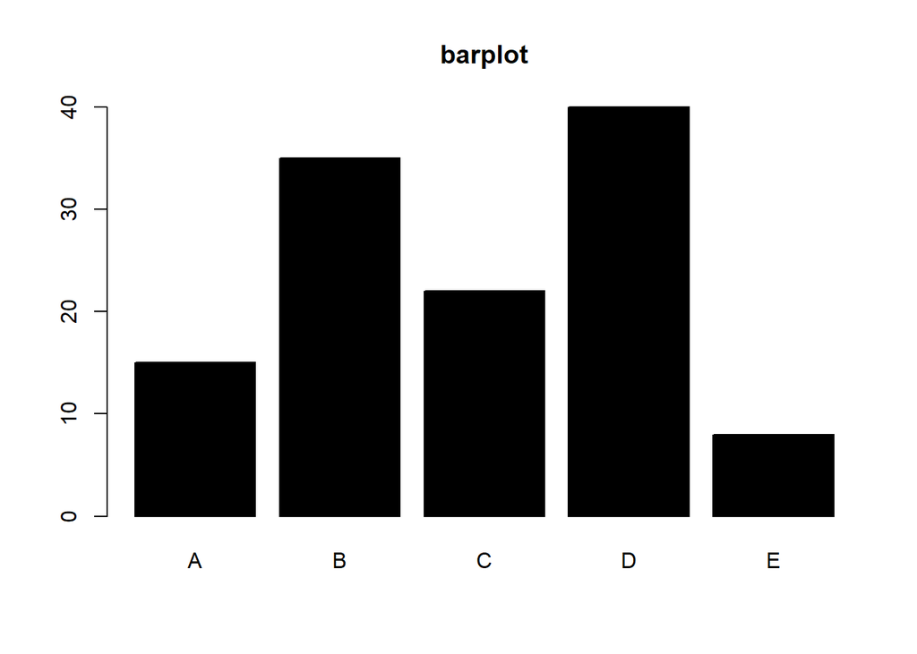

```r
 barplot(table(grpl),col="black",  main="barplot")
```

## barplot - horizontal

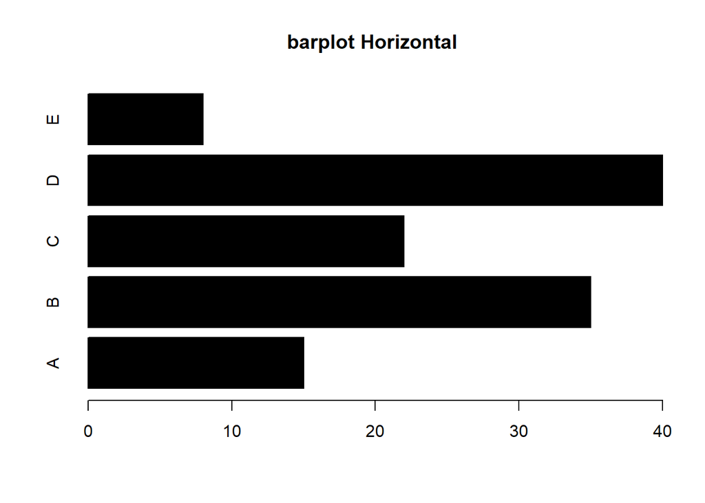

```r
 barplot(table(grpl),col="black",horiz=TRUE,
         main="barplot Horizontal")
```

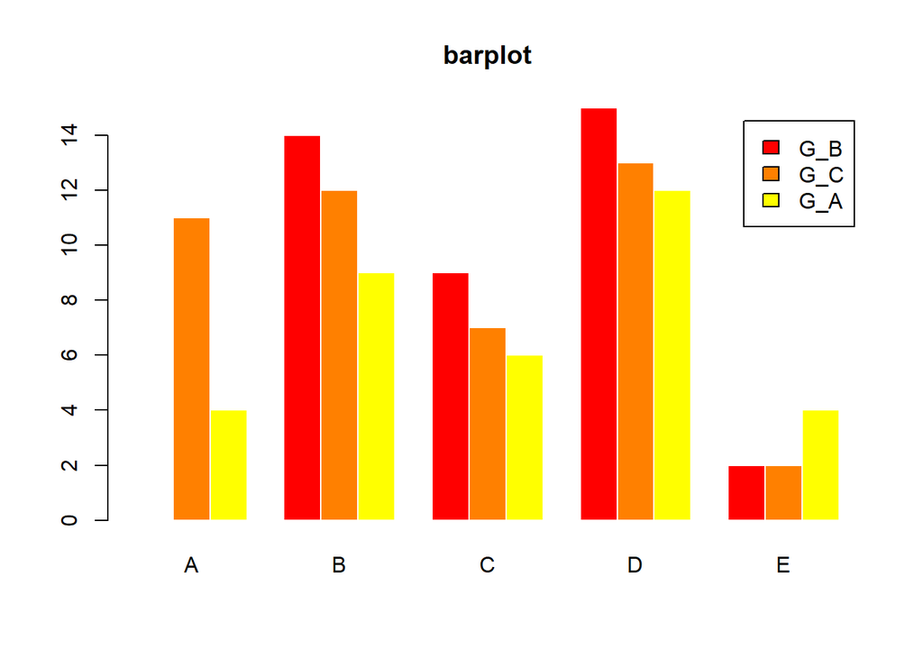

```r
 barplot(table(gg,grpl),beside=TRUE,col=heat.colors(3),
border="white",legend=unique(gg),  main="barplot")
```

## histograma

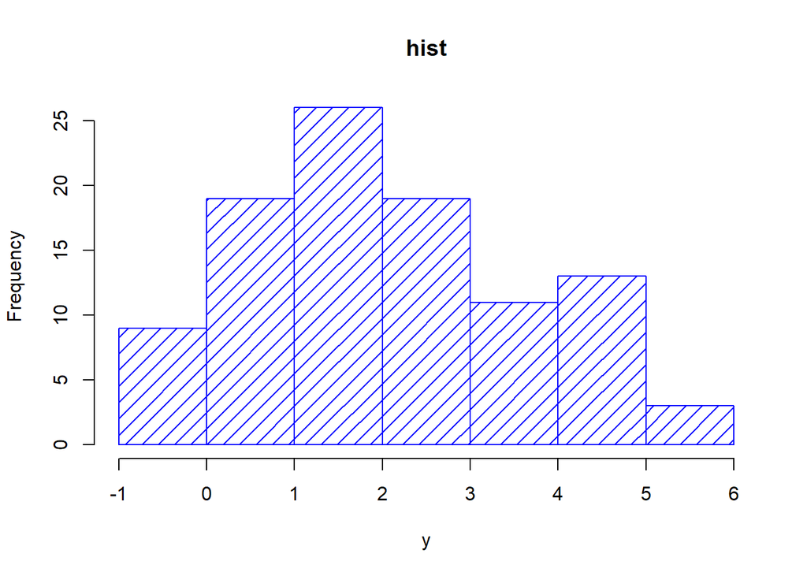

```r
hist(y,density=10,main="hist", col="blue")
```

## boxplot

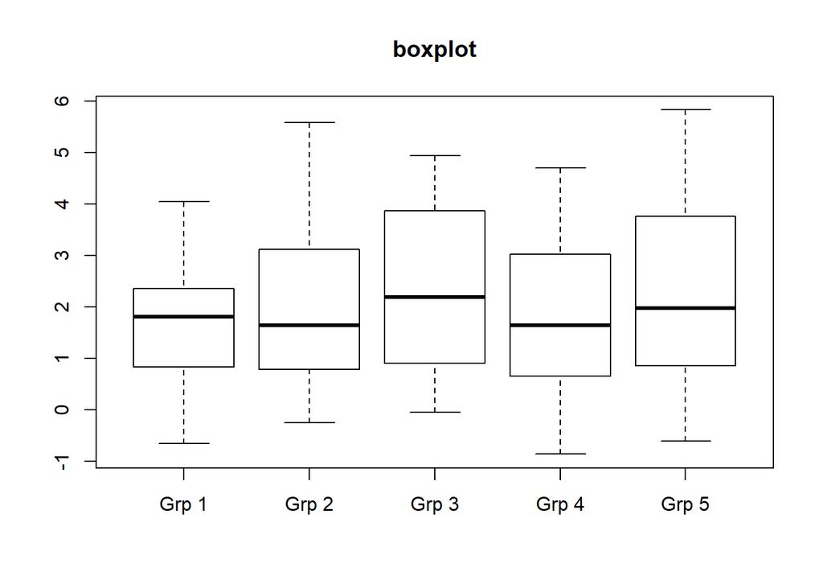

```r
 boxplot(split(y,grp),names=paste("Grp ",1:5,sep=""),
         main="boxplot")
```

## points- adiciona pontos

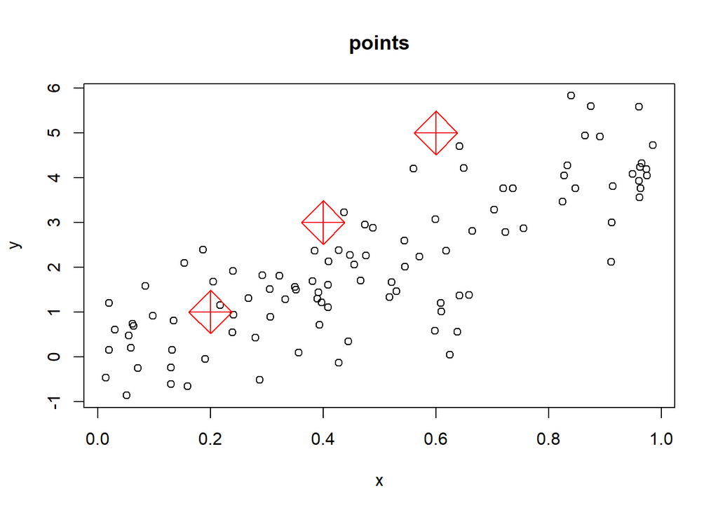

```r
 plot(x,y,type="p",main="points")
 points(c(0.2,0.4,0.6),c(1,3,5),pch=9,cex=4, col="red")
```

## abline - adiciona uma reta

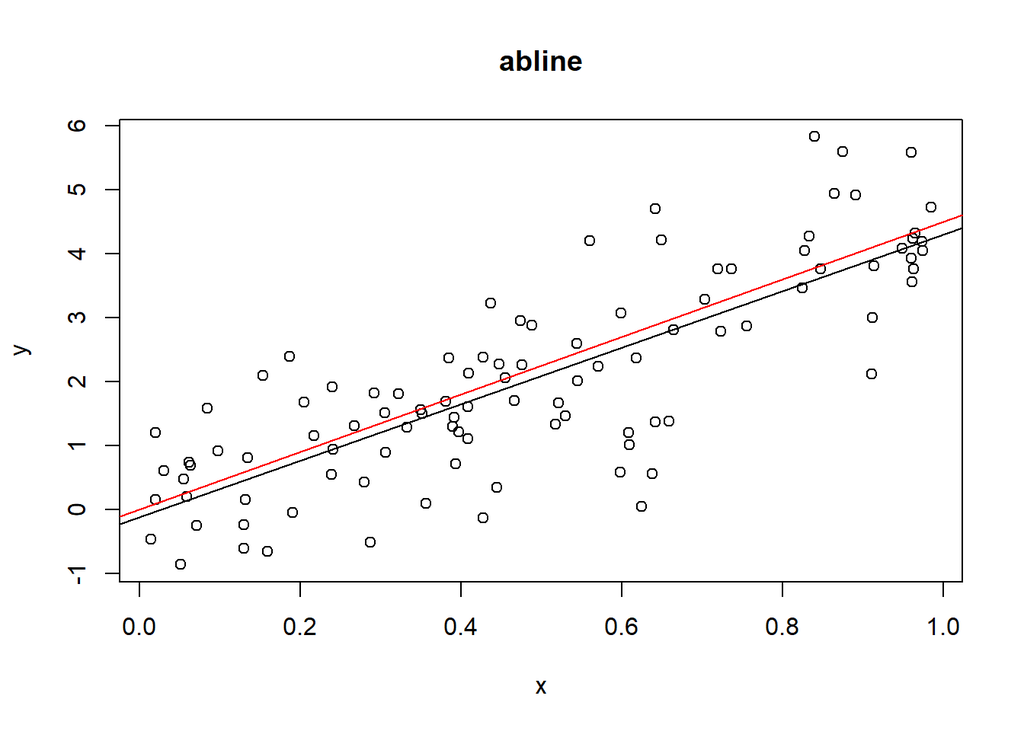

```r
 plot(x,y,main="abline")
 abline(lsfit(x,y))
 abline(a=0,b=4.5,col="red")
```

## lines - adiciona linhas

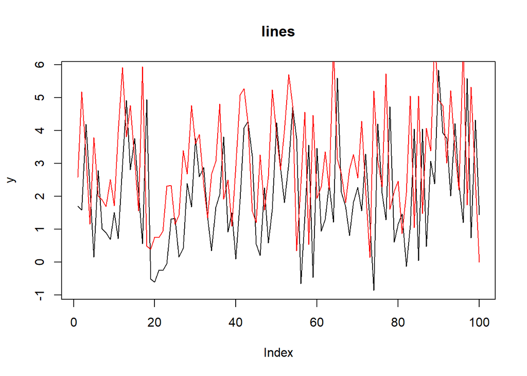

```r
plot(y,type="l",main="lines")
 lines(c(y[-1]+1,0), col="red")
```

## text - adiciona texto

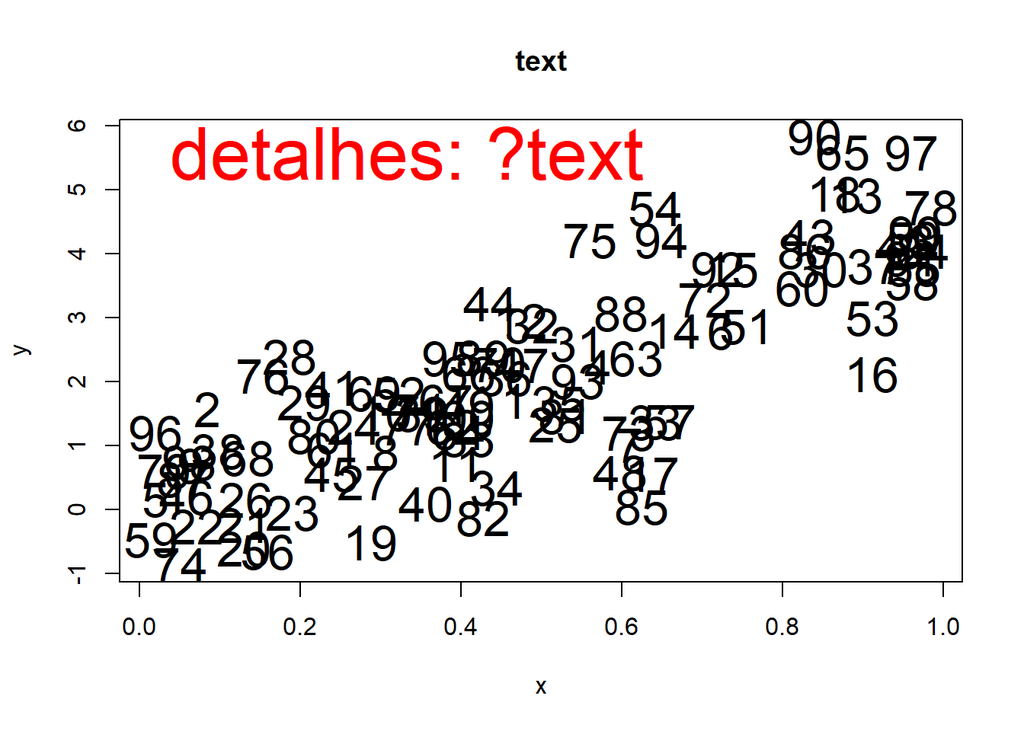

```r
plot(x,y,type="n",main="text")
text(x,y,cex=2)
text(0.02,5.5,"detalhes: ?text", pos=4, cex=3,col="red")
```

## title - gerenciando títulos

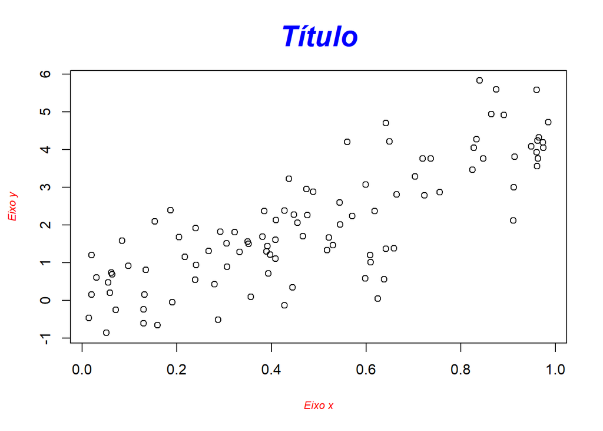

```r
plot(x,y,xlab=NA, ylab=NA)
title("Título", cex.main = 2,   font.main= 4,
      col.main= "blue",xlab = "Eixo x",ylab = "Eixo y",
      cex.lab = 0.75, font.lab = 3, col.lab = "red")
```

## Parâmetros Gráficos

- para detalhes veja *?par*
- font: 1(plain text), 2(bold face), 3 (italic) e 4 (bold italic)
- lty: 0=blank, 1=solid (default), 2=dashed, 3=dotted, 4=dotdash, 5=longdash, 6=twodash
- pch: veja *?points*

## Funções Gráficas de Baixo Nível

- Points - Adiciona pontos
- text - Adiciona texto
- lines - Adiciona linhas conectando pontos
- abline - Adiciona linha reta

## Multiplos gráficos na Janela ativa

par(mfrow=c(l ,c ))

## Funções de Gráficos

- barplot() Gráfico de barras simples
- boxplot() - box plot simples
- hist() - histograma
- dotchart() - Gráfico de pontos
- piechart() - Gráfico de pizza
- qqnorm() - Gráfico quantile-quantile para uma amostra contra a normal padrão
- qqplot quantile-quantile plot para duas amostras

## Gráficos melhores

- Para melhores resultados com gráficos use o package
  $$**ggplot2**$$
- http://www.r-graph-gallery.com/portfolio/ggplot2-package/

## Exercícios

1. Suponha a variável v2=rnorm(150,1,2). Represente-a em um gráfico de linhas. ([Solução_7.01])
2. No gráfico do item 1, inclua outra série, v3=rnorm(150,1,4), em verde escuro. As duas series ficaram bem representadas? ([Solução_7.02])
3. Sejam os dados referenes a tres marcas de carros.Faça um gráfico de pontos identificando cada marca. ([Solução_7.03])

| Marca | Vel | Dist |
| --- | --- | --- |
| A | 4 | 2 |
| B | 10 | 18 |
| C | 15 | 20 |

4. Inclua mais um resultado no gráfico do item 03. Marca D, Velocidade 35 e Distância 25. Use a cor amarela. ([Solução_7.04])
5. Faça um gráfico de pontos relacionando x e y identificando por cores os grupos **grp**. (dados simulados - slide *Criando dados Simulados*) ([Solução_7.05])